# House Number Sequence

Bo Jumrustanasan

12/18/19

## Sequence Detection

The report explores an approach to house number fill down using house number sequences. The idea is that we can be confident in filling down house numbers of records that are in the same sequence. The string of house numbers extracted from enumeration pages is divided into segments, referred to as **sequences**.

There are two main steps to detect sequences: breaking and merging. The two subprocesses are wrapped under a function called `getMergedSeq()` which returns a dataframe with a column of sequence numbers.

### Breaking Step

The string of house number is first divided into small segments, referred to as **subsequences**, so that within each subsequence,

1. there is only one parity in house numbers (either odd or even)
2. house number is only increasing (decreasing)
3. there is only one street name (only when `check_street` is set to TRUE)

See `05_00_getSequence.R` for the script.

### Merging Step

In reality, an enumerator could go back and forth from house to house within the same street. Thus, there could be both increasing and decreasing house numbers in the same sequences. Moreover, having only one parity can be too restrictive as a number can be mistranscribed into another number of different parity.

This steps merges back some subsequences into a sequence so that, within a sequence,

1. there is only 1 street name (only when `check_street` is set to TRUE)
2. there are no more than 2 house numbers whose parities are different from the rest of the house numbers in the sequence
3. Adjacent house numbers to not differ for more than 10. The number can be set by setting `jump_size`.

See `05_00_mergeSequence.R` for the script.

## House numbers by `SEQ` and `merged_SEQ`

**On us1910m_usa_sample100k.csv**

### Sample census data with `check_street` off

Sample rows with their subsequence number and merged sequence number.

- 18 Madison is treated as a mistranscription because it is the only even number among its neighboring subsequences. **very crucial to fix this before filling in missing house numbers**
- 3 Pearl is merged to the previous sequence. Moving to the new street has not been included as a condition to merge.
- 430 Pearl is not merged to the previous subsequence because the house number jump (from 3 to 430) is too large.

See below.

| house_num | best_match | SEQ | merge_SEQ |
| --- | --- | --- | --- |
| 460 | PEARL | 5 | 5 |
| 460 | PEARL | 5 | 5 |
| 460 | PEARL | 5 | 5 |
| 460 | PEARL | 5 | 5 |
| 460 | PEARL | 5 | 5 |
| 460 | PEARL | 5 | 5 |
| 460 | PEARL | 5 | 5 |
| 460 | PEARL | 5 | 5 |
| 460 | PEARL | 5 | 5 |
| 460 | PEARL | 5 | 5 |
| 460 | PEARL | 5 | 5 |
| 460 | PEARL | 5 | 5 |
| 460 | PEARL | 5 | 5 |
| 460 | PEARL | 5 | 5 |
| 460 | PEARL | 5 | 5 |
| 460 | PEARL | 5 | 5 |
| 460 | PEARL | 5 | 5 |
| 460 | PEARL | 5 | 5 |
| 460 | PEARL | 5 | 5 |
| 460 | PEARL | 5 | 5 |
| 460 | PEARL | 5 | 5 |
| 460 | PEARL | 5 | 5 |
| 460 | PEARL | 5 | 5 |
| 460 | PEARL | 5 | 5 |
| 460 | PEARL | 5 | 5 |
| 460 | PEARL | 5 | 5 |
| 460 | PEARL | 5 | 5 |
| 460 | PEARL | 5 | 5 |
| 460 | PEARL | 5 | 5 |
| 460 | PEARL | 5 | 5 |

[output cut: 271 more lines]

### Sample census data with `check_street` on

| house_num | best_match | SEQ | merge_SEQ |
| --- | --- | --- | --- |
| 460 | PEARL | 6 | 6 |
| 460 | PEARL | 6 | 6 |
| 460 | PEARL | 6 | 6 |
| 460 | PEARL | 6 | 6 |
| 460 | PEARL | 6 | 6 |
| 460 | PEARL | 6 | 6 |
| 460 | PEARL | 6 | 6 |
| 460 | PEARL | 6 | 6 |
| 460 | PEARL | 6 | 6 |
| 460 | PEARL | 6 | 6 |
| 460 | PEARL | 6 | 6 |
| 460 | PEARL | 6 | 6 |
| 460 | PEARL | 6 | 6 |
| 460 | PEARL | 6 | 6 |
| 460 | PEARL | 6 | 6 |
| 460 | PEARL | 6 | 6 |
| 460 | PEARL | 6 | 6 |
| 460 | PEARL | 6 | 6 |
| 460 | PEARL | 6 | 6 |
| 460 | PEARL | 6 | 6 |
| 460 | PEARL | 6 | 6 |
| 460 | PEARL | 6 | 6 |
| 460 | PEARL | 6 | 6 |
| 460 | PEARL | 6 | 6 |
| 460 | PEARL | 6 | 6 |
| 460 | PEARL | 6 | 6 |
| 460 | PEARL | 6 | 6 |
| 460 | PEARL | 6 | 6 |
| 460 | PEARL | 6 | 6 |
| 460 | PEARL | 6 | 6 |

[output cut: 271 more lines]

### Overview

Left: house number *subsequences*

Middle: house number *merged sequences* + street off

Right: house number *merged sequences* + street on

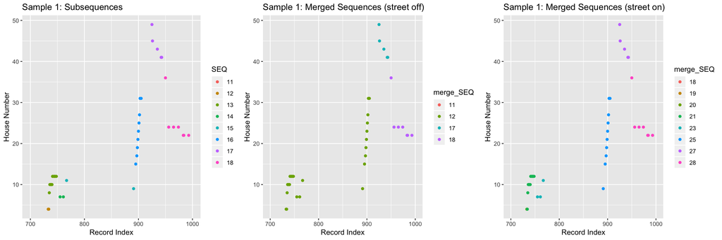

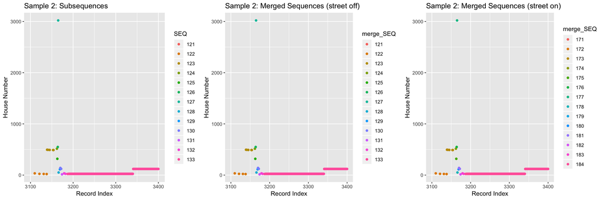

| type | cnt |
| --- | --- |
| off_merge_SEQ | 669 |
| off_SEQ | 802 |
| on_merge_SEQ | 871 |
| on_SEQ | 1022 |

### Sequence number progress

- The top line is merged sequence numbers when street names are also considered; the bottom line is when they are not.
- Different colors represent different sequnce numbers
- X axis is row numbers

#### Row number 1 - 1000

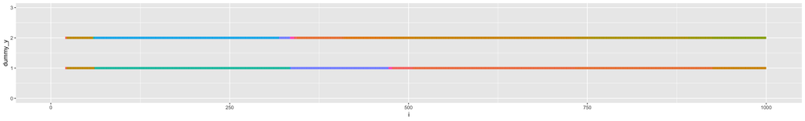

| street_off | street_on |
| --- | --- |
| 668 | 870 |

## Sample rows where sequences do not agree.

### Sequences that are detected using `best_match` can generate more reliable sequences.

| microfilm | ED | house_num | best_match | SEQ | i | merge_SEQ |
| --- | --- | --- | --- | --- | --- | --- |
| NA | 0020 | 460 | PEARL | 5 | 314 | 6 |
| NA | 0020 | 460 | PEARL | 5 | 315 | 6 |
| NA | 0020 | 460 | PEARL | 5 | 316 | 6 |
| NA | 0020 | 460 | PEARL | 5 | 317 | 6 |
| NA | 0020 | 460 | PEARL | 5 | 318 | 6 |
| NA | 0020 | NA | PARK ROW | 5 | 319 | 7 |
| NA | 0020 | NA | PARK ROW | 5 | 320 | 7 |
| NA | 0020 | NA | PARK ROW | 5 | 321 | 7 |
| NA | 0020 | NA | PARK ROW | 5 | 322 | 7 |
| NA | 0020 | NA | PARK ROW | 5 | 323 | 7 |
| NA | 0020 | NA | PARK ROW | 5 | 324 | 7 |

| microfilm | ED | house_num | best_match | SEQ | i | merge_SEQ |
| --- | --- | --- | --- | --- | --- | --- |
| NA | 0029 | NA | OLIVER | 104 | 2853 | 146 |
| NA | 0029 | NA | OLIVER | 104 | 2854 | 146 |
| NA | 0029 | 376 | WATER | 106 | 2855 | 147 |
| NA | 0029 | 372 | WATER | 106 | 2856 | 147 |
| NA | 0029 | 370 | WATER | 106 | 2857 | 147 |
| NA | 0029 | 6 | JAMES SLIP | 106 | 2858 | 148 |
| NA | 0029 | 4 | JAMES SLIP | 106 | 2859 | 148 |
| NA | 0029 | 2 | JAMES SLIP | 106 | 2860 | 148 |
| NA | 0029 | NA | JAMES SLIP | 106 | 2861 | 148 |
| NA | 0029 | NA | JAMES SLIP | 106 | 2862 | 148 |
| NA | 0029 | NA | JAMES SLIP | 106 | 2863 | 148 |

| microfilm | ED | house_num | best_match | SEQ | i | merge_SEQ |
| --- | --- | --- | --- | --- | --- | --- |
| NA | 0046 | 11 | BROADWAY E | 249 | 6326 | 333 |
| NA | 0046 | NA | BROADWAY E | 249 | 6327 | 333 |
| NA | 0046 | 13 | BROADWAY E | 249 | 6328 | 333 |
| NA | 0046 | NA | BROADWAY E | 249 | 6329 | 333 |
| NA | 0046 | NA | BROADWAY E | 249 | 6330 | 333 |
| NA | 0046 | 13 | DOYERS | 249 | 6331 | 335 |
| NA | 0046 | NA | DOYERS | 249 | 6332 | 335 |
| NA | 0046 | 15 | DOYERS | 249 | 6333 | 335 |
| NA | 0046 | NA | DOYERS | 249 | 6334 | 335 |
| NA | 0046 | NA | DOYERS | 249 | 6335 | 335 |
| NA | 0046 | NA | DOYERS | 249 | 6336 | 335 |

### Mistranscription detected.

1. `SEQ` and `merged_SEQ` do not agree at record *3 PEARL*. This is a mistranscription. Records where i = 59 and 60 should have been 3 MADISON and NA MADISON.

| microfilm | ED | house_num | best_match | SEQ | i | merge_SEQ |
| --- | --- | --- | --- | --- | --- | --- |
| NA | 0020 | NA | MADISON | 2 | 54 | 2 |
| NA | 0020 | NA | MADISON | 2 | 55 | 2 |
| NA | 0020 | NA | MADISON | 2 | 56 | 2 |
| NA | 0020 | NA | MADISON | 2 | 57 | 2 |
| NA | 0020 | NA | MADISON | 2 | 58 | 2 |
| NA | 0020 | 3 | PEARL | 2 | 59 | 5 |
| NA | 0020 | NA | PEARL | 2 | 60 | 5 |
| NA | 0020 | 430 | PEARL | 5 | 61 | 6 |
| NA | 0020 | NA | PEARL | 5 | 62 | 6 |
| NA | 0020 | NA | PEARL | 5 | 63 | 6 |
| NA | 0020 | 432 | PEARL | 5 | 64 | 6 |

| microfilm | ED | house_num | best_match | SEQ | i | merge_SEQ |
| --- | --- | --- | --- | --- | --- | --- |
| NA | 0023 | NA | MADISON | 34 | 1139 | 50 |
| NA | 0023 | NA | MADISON | 34 | 1140 | 50 |
| NA | 0023 | NA | MADISON | 34 | 1141 | 50 |
| NA | 0023 | 66 | MADISON | 34 | 1142 | 50 |
| NA | 0023 | 52 | MADISON | 35 | 1143 | 51 |
| NA | 0023 | NA | CATHERINE | 35 | 1144 | 52 |
| NA | 0023 | 54 | CATHERINE | 35 | 1145 | 52 |
| NA | 0023 | 56 | CATHERINE | 35 | 1146 | 52 |
| NA | 0023 | NA | CATHERINE | 35 | 1147 | 52 |
| NA | 0023 | NA | CATHERINE | 35 | 1148 | 52 |
| NA | 0023 | 58 | CATHERINE | 35 | 1149 | 52 |

## Next Steps

- More rigorous way to detect the *3 PEARL* and *52 MADISON* case.
- EDA on fill down in segments where subsequences and sequences agree.
- EDA on records around points where subsequences and sequences do not agree.

.